# DATA100 Introduction to Data Analytics

Lecture 18: Predictive Modelling

Agassi Iu

Wilfrid Laurier University

2026-11-26

## Where we left off

**Recall from last class**

We added structure to a linear model (i.e. categories, several predictors).

Last class ended with a question: *how do we know a model works on data it has not seen?*

**Today’s Agenda:**

- split our data into a **training set** and a **test set**
- measure how well a model predicts, against a simple *baseline*
- predict a binary outcome with **logistic regression**

## Motivation: Studying

**How do you prepare for an exam?**

Suppose that a resourceful student got their hands on last year’s exam, they memorized all of the answers word-for-word. Do you think if they would do well on a **new** exam?

**A model can do the same**

Basically it fit the data it learned from very closely (like past exam questions), and there is a possibility that it still miss on **new** cases (new exam questions).

To find out whether the model is good, we need to test the model on data it has **never seen**.

## What is predictive modelling?

Models do different jobs:

- Descriptive: summarize a pattern in the data
- Inferential: test a claim about the world
- **Predictive:** estimate values for cases we have **not observed**

**Today’s goal**

Predict the outcome for a **new** student. What matters is not how well the model fits the students we already have, but how well it does on the next ones.

# Look before you model

## The outcome

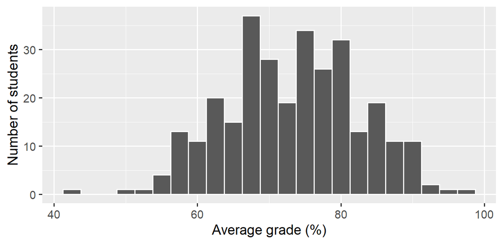

Roughly bell-shaped and centred in the low 70s, with a few unusual grades at either end.

## A checklist before modelling

**Before you fit anything, ask**

1. What does the outcome look like? Is it skewed or oddly shaped?
2. Are there unusual values in the outcome or the predictors?
3. Do any predictors overlap a lot (multicollinearity)?
4. How do the predictors relate to the outcome?

Exploring first is what tells you which modelling choices make sense.

# Spending our data

## Training set and test set

We have a limited amount of data, so we split it in two.

|  | Training set | Test set |
| --- | --- | --- |
| **What it is** | The data we use to **build** the model | Data we put aside for later |
| **Used for** | Fitting the model | Checking how well it predicts **new** cases |
| **How often** | As many times as we like | Once at the end |

## The basic rule

**A common split: 80% / 20%**

Put about **80%** of the data in the training set and about **20%** in the test set, chosen **at random**.

- Too little training data: the model learns poorly
- Too little test data: the score is unreliable
- There is no perfect ratio, and 80/20 is a sensible default

## Example: splitting the survey

**The tidymodels split functions**

- `initial_split()` randomly decides which rows belong to the training set and which to the test set. `prop = 0.80` is the share that goes to training.
- `training()` pulls out the training rows, and `testing()` pulls out the test rows.

**What does set.seed() do?**

The split is random every time you run the code, but `set.seed()` makes it so that it repeats the **same** random choice every time, so everyone with the same seed gets the same answer.

## Fancier splits (out of scope)

**You know what? You can do more than this, but it is out of scope**

- **Stratified splits:** keep the mix of groups (or outcome values) the same in both sets, with `initial_split(..., strata = )`
- **Time-based splits:** train on the past, test on the most recent data, with `initial_time_split()`
- **Validation sets and resampling:** a third set, or repeated splits, for choosing between models
- **Grouped data:** keep all rows from one person or unit together

If you’re curious, read [Tidy Modeling with R, Chapter 5](https://www.tmwr.org/splitting).

# Predicting a grade

## The baseline: guess the average

The simplest “model” gives every student the average grade of the training set.

```r
baseline <- mean(train$avg_grade)
baseline
```

```
[1] 72.90917
```

**A model has to beat the baseline**

If a model cannot do better than guessing the average, then it is not worth using.

## Measuring the error

For each student, the **error** is the gap between the actual grade and the prediction.

**Root mean squared error (RMSE)**

It is a statistical tool that we use to measure the “typical size of an error”, in the same units as the outcome (grade points). A model with smaller RMSE is better.

```r
rmse <- function(actual, predicted) sqrt(mean((actual - predicted)^2))
```

The baseline’s typical error is about the standard deviation of the grades.

## Three models

Recall from last time, we used `lm()` to formulate our linear regression model.

```r
# 1. Simple: study hours and program
fit_simple <- lm(avg_grade ~ study_hours_week + program, data = train)

# 2. Flexible: everything, plus interactions with program
fit_flex <- lm(
  avg_grade ~ (study_hours_week + sleep_hours + sleep_quality +
               stress_level + num_courses + work_hours_week) * program +
              favourite_drink + has_early_class,
  data = train
)
```

The flexible model has many more coefficients, so it can bend itself closely around the training data.

## Errors on the training data

```r
train_error <- tibble(
  model = c("Baseline standard deviation", "Study hours + program", "Everything + interactions"),
  train_error = c(
    rmse(train$avg_grade, baseline),
    rmse(train$avg_grade, fitted(fit_simple)),
    rmse(train$avg_grade, fitted(fit_flex))
  )
)
train_error
```

```
# A tibble: 3 × 2
  model                       train_error
  <chr>                             <dbl>
1 Baseline standard deviation        9.17
2 Study hours + program              4.75
3 Everything + interactions          4.39
```

## Now the test set

```r
results <- train_error |>
  mutate(test_error = c(
    rmse(test$avg_grade, baseline),
    rmse(test$avg_grade, predict(fit_simple, test)),
    rmse(test$avg_grade, predict(fit_flex, test))
  ))
results
```

```
# A tibble: 3 × 3
  model                       train_error test_error
  <chr>                             <dbl>      <dbl>
1 Baseline standard deviation        9.17       9.79
2 Study hours + program              4.75       5.77
3 Everything + interactions          4.39       6.16
```

## Training vs. test error

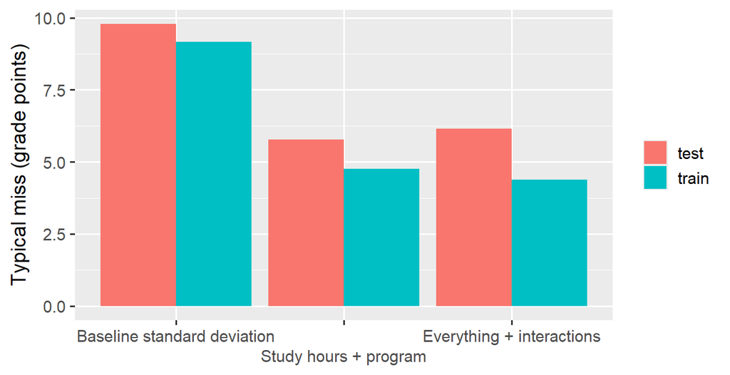

```r
results |>
  pivot_longer(c(train_error, test_error), names_to = "set", values_to = "error") |>
  mutate(set = str_remove(set, "_error"), model = fct_inorder(model)) |>
  ggplot(aes(x = model, y = error, fill = set)) +
  geom_col(position = "dodge") +
  scale_x_discrete(guide = guide_axis(n.dodge = 2)) +
  labs(x = NULL, y = "Typical miss (grade points)", fill = NULL)
```

## What do we see?

- The baseline scores about the same on both sets: it learned almost nothing
- Adding study hours and program helps a lot
- A more flexible model always fits its training data a little better. The question is whether that carries over to the test set

**Overfitting**

A model that follows the quirks of its training data too closely, and then does worse on new data. Training error alone cannot show it.

# Predicting binary variables

## A yes/no outcome

So far the outcome has been a number. What if the question is yes or no? For example: can I predict whether a student has an early class in the morning?

```r
train |>
  count(has_early_class) |>
  mutate(share = n / sum(n))
```

```
# A tibble: 2 × 3
  has_early_class     n share
  <chr>           <int> <dbl>
1 No                134 0.558
2 Yes               106 0.442
```

`early_class` is **1** for yes and **0** for no. Roughly six in ten students have no early class, so our baseline is to **always guess “No”**.

## Why not a straight line?

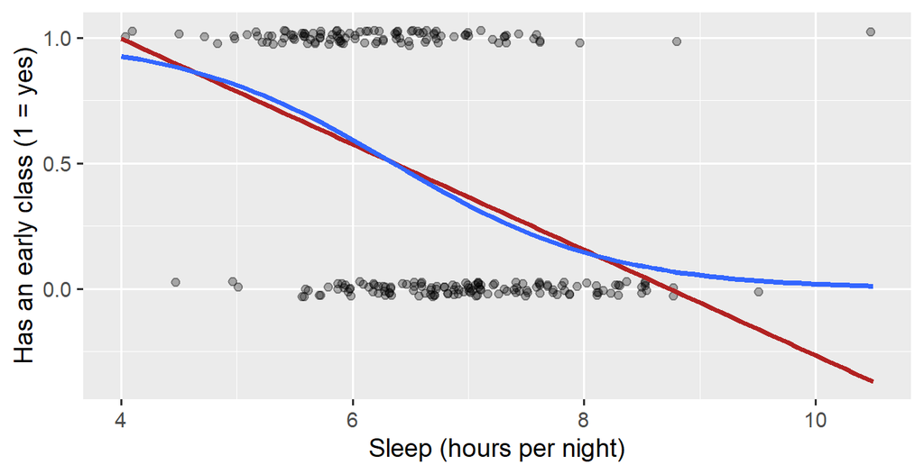

```r
ggplot(train, aes(x = sleep_hours, y = early_class)) +
  geom_jitter(height = 0.03, alpha = 0.3) +
  geom_smooth(method = lm, se = FALSE, color = "firebrick") +
  geom_smooth(method = "glm", method.args = list(family = "binomial"), se = FALSE) +
  labs(x = "Sleep (hours per night)", y = "Has an early class (1 = yes)")
```

## Logistic regression

**Logistic regression**

A model for a binary outcome. The `glm()` is like `lm()` with `family = binomial` says the outcome is yes/no. We are going to skip the inference for logistic regression in this course. The interpretation for the coefficients are very different. Take ST494 if you are interested :D

```r
logit_fit <- glm(early_class ~ sleep_hours, data = train, family = binomial)
summary(logit_fit)
```

```
Call:
glm(formula = early_class ~ sleep_hours, family = binomial, data = train)

Coefficients:
            Estimate Std. Error z value Pr(>|z|)
(Intercept)   6.8225     1.1848   5.758 8.51e-09 ***
sleep_hours  -1.0738     0.1805  -5.948 2.71e-09 ***
---
Signif. codes:  0 '***' 0.001 '**' 0.01 '*' 0.05 '.' 0.1 ' ' 1

(Dispersion parameter for binomial family taken to be 1)

    Null deviance: 329.44  on 239  degrees of freedom
Residual deviance: 282.20  on 238  degrees of freedom
AIC: 286.2

Number of Fisher Scoring iterations: 4
```

## From probabilities to predictions

```r
test_results <- test |>
  mutate(
    probability = predict(logit_fit, test, type = "response"),
    predicted   = if_else(probability > 0.5, 1, 0)
  )

test_results |>
  select(sleep_hours, probability, predicted, early_class) |>
  head(6)
```

```
# A tibble: 6 × 4
  sleep_hours probability predicted early_class
        <dbl>       <dbl>     <dbl>       <dbl>
1         4.6       0.868         1           1
2         5         0.811         1           1
3         5.8       0.644         1           1
4         7.1       0.310         0           0
5         6.2       0.541         1           0
6         7.8       0.175         0           0
```

To get a yes or no, pick a **cutoff**. A common choice is **0.5**: predict yes when the probability is above it.

## Model Accuracy

```r
mean(test_results$predicted == test_results$early_class)   # model accuracy
```

```
[1] 0.6666667
```

```r
table(actual = test_results$early_class, predicted = test_results$predicted)
```

```
      predicted
actual  0  1
     0 32 12
     1  8  8
```

**Accuracy**

The share of predictions that are correct. The table counts correct and incorrect predictions for each actual answer.

## Exercise

**Try it yourself**

1. Split `survey` 80/20 with a seed of your choice.
2. Fit a logistic model for `early_class` using `sleep_hours` and `stress_level` on the training set.
3. Compute the test accuracy, and compare it with always guessing “No”.
4. Change the seed and run it again. Does the accuracy change?

## More than two categories

What if the outcome has **several** categories, such as `program`?

- One idea: fit one yes/no model per program (“is it Arts or not?”), then pick the program with the **highest probability**
- `multinom()` does this in one step, and the probabilities across programs add up to 1

```r
library(nnet)

program_fit <- multinom(program ~ avg_grade + study_hours_week,
                        data = train, trace = FALSE)

program_pred <- predict(program_fit, test)   # predicted program for each test student
```

## Can I guess someone’s program?

```r
mean(program_pred == test$program)     # accuracy
```

```
[1] 0.7833333
```

```r
table(actual = test$program, predicted = program_pred)
```

```
             predicted
actual        Arts Business Engineering Health Sci Science
  Arts          11        0           0          0       0
  Business       2        9           0          0       0
  Engineering    0        0           9          5       0
  Health Sci     1        0           2          7       0
  Science        0        2           0          1      11
```

**A slightly artificial question**

In real life we would rarely predict a student’s program from their grade. It is just a convenient example of more than two categories.

## Summary

- Predictive modelling cares about new data, not just the data we have
- Training set builds the model; test set validates it.
- A flexible model can look great on training data and overfit
- Logistic regression predicts a probability for a binary outcome